# R4BD

Tinashe Makuti

01/02/2021

# Programming with R

As we saw, R is a great tool to make calculations and plots but it can be also used as a programming language, which is especially interesting when you would like to advanced things.

## Basics of R programming

Among the basics, we habe the different loops and test functions

- the `for` loop:

A basic example:

```r
for (i in 1:10){
  print(i+1)
}
```

```
## [1] 2
## [1] 3
## [1] 4
## [1] 5
## [1] 6
## [1] 7
## [1] 8
## [1] 9
## [1] 10
## [1] 11
```

When there is only one command in the for, you can avoid the braces in the following way

```r
for(i in 1:10) print(i + 1)
```

```
## [1] 2
## [1] 3
## [1] 4
## [1] 5
## [1] 6
## [1] 7
## [1] 8
## [1] 9
## [1] 10
## [1] 11
```

The `for` loop can be used also as follows:

```r
list = c('tyty', 'tata', 'tutu')
for (i in list) print(i)
```

```
## [1] "tyty"
## [1] "tata"
## [1] "tutu"
```

- the `while` loop:

```r
while(condition){
  commands to execute
  ...
  update the condition
}
```

A practical example for that:

```r
k = 0
test <- (k < 10)
while(test){
  print(k)
  k = k + 1
  test = (k < 10)
}
```

```
## [1] 0
## [1] 1
## [1] 2
## [1] 3
## [1] 4
## [1] 5
## [1] 6
## [1] 7
## [1] 8
## [1] 9
```

An alternative would be:

```r
k = 0
while(k < 10){
  print(k)
  k = k + 1
}
```

```
## [1] 0
## [1] 1
## [1] 2
## [1] 3
## [1] 4
## [1] 5
## [1] 6
## [1] 7
## [1] 8
## [1] 9
```

- the `switch` function:

```r
out = switch (expression,
  case1 = action1,
  case2 = action2,
  ...
)
```

In practice, we have something like:

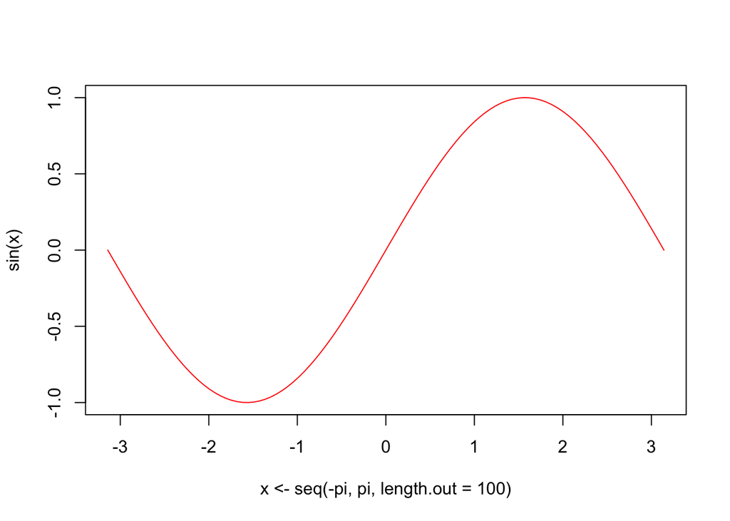

```r
exp = 1

switch(exp,
       "1" = plot(x <- seq(-pi, pi, length.out = 100), sin(x), type='l',
             col = 'red'),
       "2"=  plot(x <- seq(-pi, pi, length.out = 100), sin(x), type='l',
             col = 'red'))
```

- the `if` function:

```r
if(condition){
  some commands to execute
  ...
} else {
  some alternative commands
  ...
}
```

In practice:

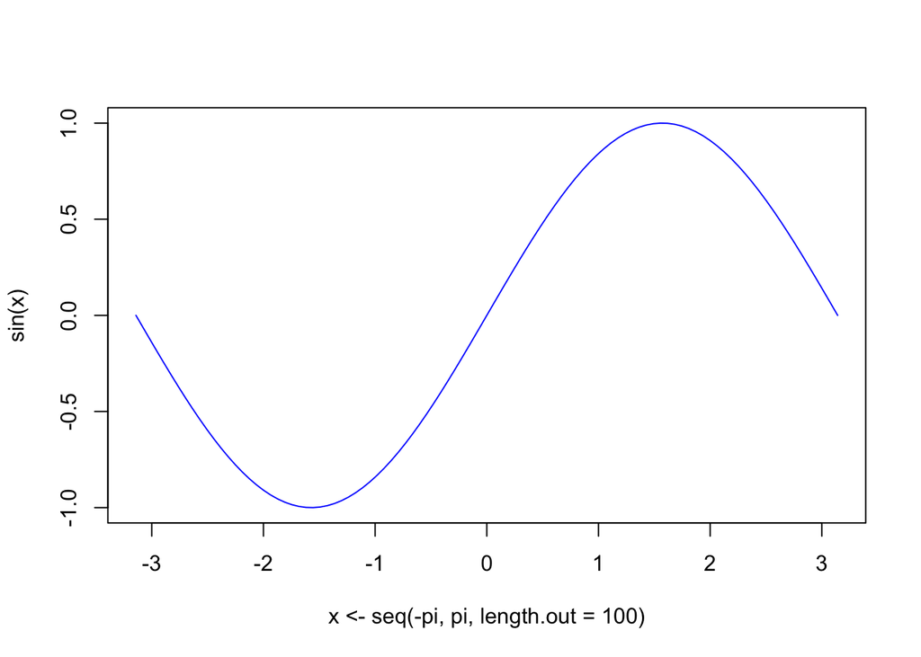

```r
plot = 'cos'

if(plot == 'sin'){
 plot(x <- seq(-pi, pi, length.out = 100), sin(x), type='l',
             col = 'red')
} else {
  plot(x <- seq(-pi, pi, length.out = 100), sin(x), type='l',
             col = 'blue')
}
```

## Defining functions in R

In some situations, it is necessary to be able to define new functions, which will be resued in some parts of a long code.

The format to define a function is as follows:

```r
name_of_function <- function(prm1, prm2m, ...){
  a first command
  a second command
  ...
  the_object_to_return # or return(the_object_to_return)
}
```

> Remark: the object to return could be a single vector/matrix/data.frame or list if you would like to return several objects A couple of examples:

```r
mysum <- function(x,y){
  s = x+y
  s
}

mysum2 <- function(x,y){
  s = x + y
  s2 = x^2 + y^2
  list(s = s, s2 = s2)
}

x = 2; y = 5
mysum(x,y)
```

```
## [1] 7
```

```r
mysum2(x,y)
```

```
## $s
## [1] 7
##
## $s2
## [1] 29
```

> Exercise: create a function `myhist` that plot an histogram for some data, with an estimation of the density as an option

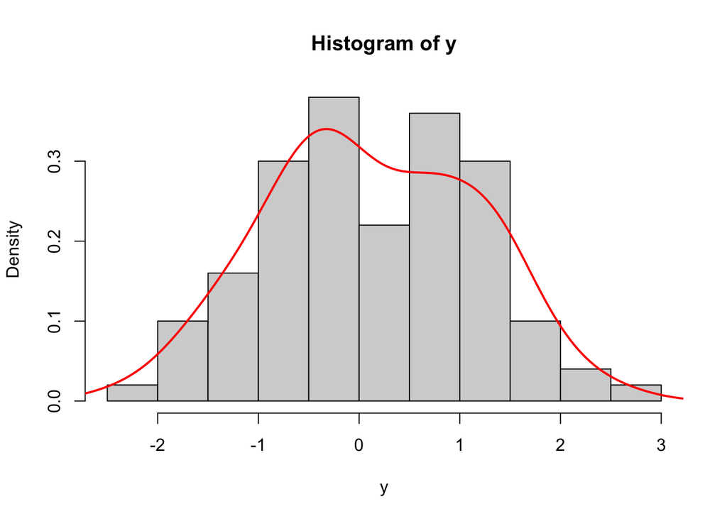

```r
myhist <- function(y, isDensity = FALSE){
  hist(y, freq = FALSE)
  if(isDensity) lines(density(y),lwd=2,col='red')
}

myhist(rnorm(100), TRUE)
```

> The functions defined in this way are available until the restart of R.

> If a new function has the same as an existing R function, the original function will not be available until restart

> The variables that are defined in a function are not available in the enviroment (function scoping)

The `...` operator allows to provide extra arguments to a function which will be passed to the subfunctions that are called in the function. This operator is extremely useful to exploit all options of subfunctions without managing all these possibilities. For instnace, the `hist` function has manay options but when creating my `myhist` function, i dont want to manage each of the these option: the `...` operator will do it for me!

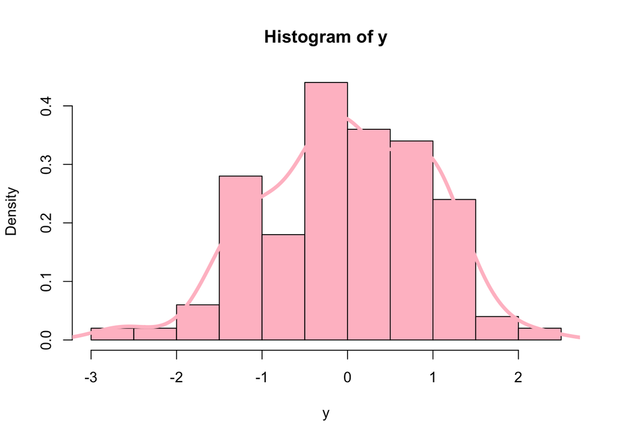

```r
myhist <- function(y, isDensity = FALSE, ...){
  hist(y, freq = FALSE, ...)
  if(isDensity) lines(density(y),lwd=4,...)
}

myhist(rnorm(100), TRUE, col = 'pink')
```

> Exercise: modify the function such that the density line can be dashed, using the `...` operator

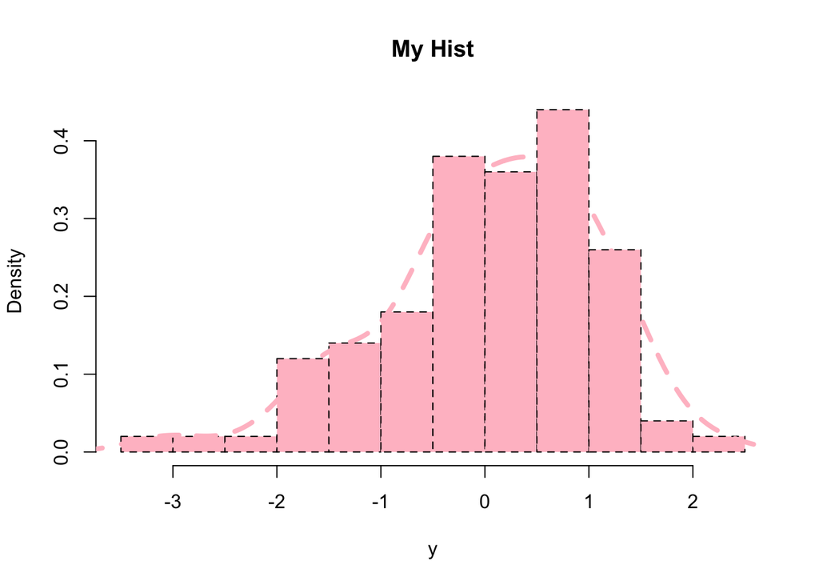

```r
myhist(rnorm(100), TRUE, col = 'PINK', lty =2, main = 'My Hist')
```

> Remark: in this case, all subfunctions follow the options that are provided to the main function

Just to illustrate how functions work in practice, let’s consider the following example

```r
z = 4
myfun <- function(x,y,...){
  s = x + y
  s2 = x + y + z

  list(s,s2)
}

out = myfun(2,5)
out
```

```
## [[1]]
## [1] 7
##
## [[2]]
## [1] 11
```

> Remark: thanks to this exampole, we understand that functions can inherit from global variables that are existing the in environment, but all variables that are created within a function are not visible outside

This may lead to classiscal errors, such that:

```r
z = 4
myfun <- function(x,y,...){
  Z = x + y
  s2 = x + z
}

out = myfun(2,5)
out
```

```
## [1] 6
```

> This situation is a classical bug which can be very difficult to catch if in the middle of doezens of code lines

Regarding the way we can provide information as input parameters, R is extremely flexible in the sense the input paramters can provided in any order if it is explicit:

```r
x = rnorm(100)
a = seq(-pi, pi, length.out = 100)
b = sin(x)

plot(a,b,type='l', col='red')
```

but the following call is ok as well:

```r
plot(type='l', y =b, col='red', x=a)
```

```r
#in this case you will need to provide all the arguments with their keywords (names)
```

So, we can either pass the input arguments in the order provided by the documentation, or pass the argument in any order, if we are explicity on the each role of each argument

> Remark: there is no need to provide the full argument name if a few first letters are sufficient to identify it.

```r
plot(ty = 'l', y = b, col = 'red', x = a)
```

Here the use of `'ty='l'` or `t='l'` are equivalent to `type='l'` because there are no other argument names starting with “t” or “ty”

This allows package provisers to use long and explicit names for their arguments, but users can shorten them when calling the function if there is no ambiguity

```r
myfun <- function(x, mylongparamter=2){
  s = x + mylongparamter
}

out = myfun(2, m =3)
out
```

```
## [1] 5
```

A final comment about writing R functions is to also provide names for output parameters that are explicit as possible

```r
myfun2 <- function(x, mylongparameter=2){
  s = x + mylongparameter
  s2 = x^2 + mylongparameter^2

  return(list(sum = s, squaredSum = s2))
}

out = myfun2(2,m=3)
out$sq
```

```
## [1] 13
```

> Remark to save the functions you develop, you can either keep them in a R script that you source every time you need it, or create a personal R package (see next subsection)

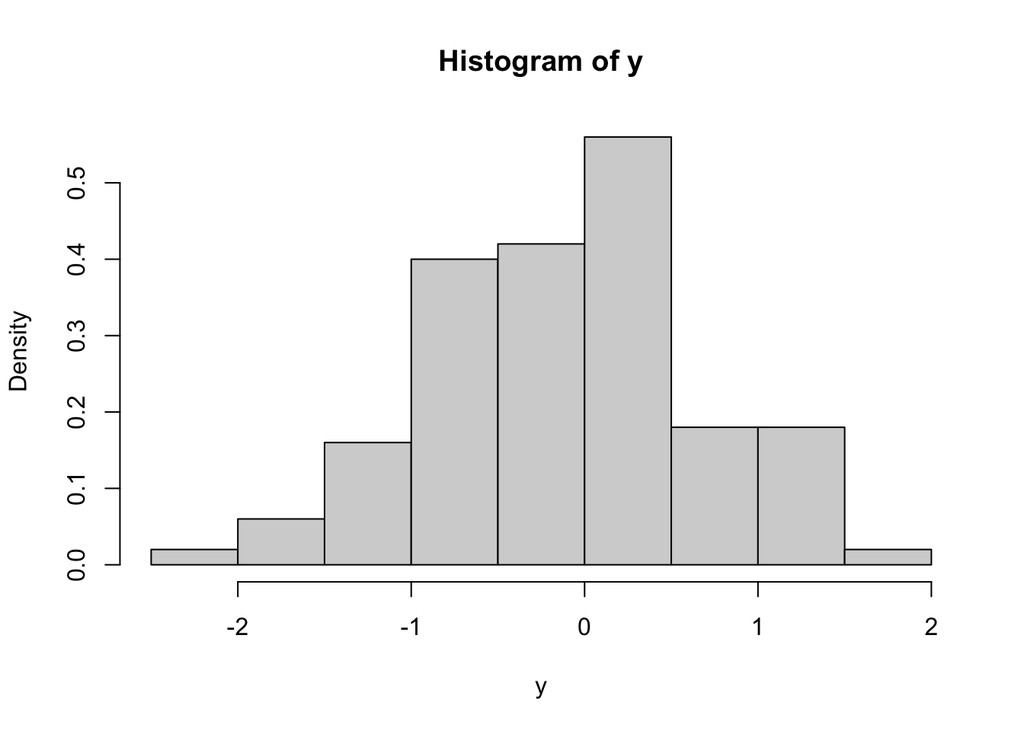

```r
rm(list = ls())
source('/Users/nashe/code/ml/dsti/myFunctions.R')
myhist(rnorm(100), is = TRUE)
```

## Building R packages - start with a clear environment -load all functions and data you want ot add inyour package -then call the package

```r
rm(list = ls())

x = rnorm(100)

myhist <- function(y, isDensity = FALSE, ...){
  hist(y, freq = FALSE, ...)
  if(isDensity) lines(density(y),lwd=4,...)
}


#package.skeleton(name="myPack")
```

The folder `myPack` which has been created in the working directory contains the sources of mypackage. We now have to edit the files that are in this folder to complete the documentation

The next steps are required befloe compiling the package. -Edit the `DESCRIPTION` file - edit the documentation file of the `MAN` directory of each object and function you provide in the package

Once you complete these steps, you can compile the package. For this, you will have to open a terminal and type in the appropriate directory:

-`R CMD check myPack` to test if everything is ok with the package -if yes, you can buikd it with `R CMD build mypack

If your package passed the check and compiles, you will get an archive `myPAck.0.1.tgz`, which you caan either share or upload on the CRAN server.

A web form to submit a pakcage on the CRAN is available at https://cloud.r-project.org

you can install

```r
install.packages('path', repos = NULL)
```

# Creating interactive websites with Shiny

In a lot of situations, you may want to allow someone to interact with your code but the person doesn’t know R. In such a case, the `shiny` package will help you build a simple interactive (web) application allowing this person to play with your code and data. The `shiny` package offers you to create interactive websites using javascript and allowing to call R in a dynamic manner. It could be used to do some POC (proof of concept) for a software based on your work.

```r
#install.packages("shiny")
library(shiny)
```

A first example can be seen by running:

```r
runExample("01_hello")
```

To create your own Shiny server, you’ll have to create in a folder two specific files:

- `ui.R` is devoted to describe the user interface,
- `server.R` is devoted to decribes the R commands to run when the user plays with the interface.

The combination of these two files is a “Shiny App”.

As an example, here is a minimal `ui.R`:

```r
library(shiny)

ui <- fluidPage(

  titlePanel("Hello Shiny")

  sidebarLayout(
    sidebarPanel(
      sliderInput(inputId = "bins",
                  label = "Number of bins",
                  min = 1, max = 50,
                  value = 25)
    ),
    mainPanel(
      plotOutput(outputId = "histplot")
    )
  )
)
```

and a minimal `server.R` file could be:

```r
server <-  function(input,output){
  output$histplot <- renderPlot({
    x = rnorm(100)
    bins = seq(min(x),max(x),length.out = input$bins+1)
    hist(x,breaks = bins,col='lavender',main = "my histogram")
  }
  )
}
```

> Exercise: customize the previous Shiny app to display a histogram with a estimation of the density on it.

```r
server <-  function(input,output){
  output$histplot <- renderPlot({
    x = rnorm(100)
    bins = seq(min(x),max(x),length.out = input$bins+1)
    hist(x,breaks = bins, freq = FALSE,
         col='lavender',main = "my histogram")
    lines(density(x),lty=2, lwd=4, col='pink')
  }
  )
}
```

As we saw, it is possible to modify the presentation of the html page in the `UI.R` file. It is also possible to add “buttons”, such as chexk boxes, sliders, action buttons, …

- `actionButton`: action button,
- `checkboxInput`: a single check box,
- `fileInput`: to iput a specific file,
- `numericInput`: a field to enter a numeric value,
- `sliderInput`: a slider to change a numeric parameter,
- `radioButtons`: a set of radio buttons (for categorical variables),
- `textInput`: a field to enter some text,
- `submitButton`: to run some action,
- `selectInput`: pick a choice in a list

Once the UI page is correctly designed and parametized, you’ll have to use the outputs of those buttons in the R code within the server part: the result of each button will be avaialble in the `input$name_of_the_button` in the `server.R`.

For instance, the result of the button `checkboxInput(inputId="check",label='This is a label',value = TRUE)` will be available in the `server.R` part in `input$check` (it will be here `TRUE` or `FALSE`).

> Exercise: simulate some data and save them in a CSV file on your disk. Then, create a shiny app which is able to: 1) load the file by using a `fileInput` button, 2) plot a histogram with a density estimation function, where it is possible to activate or not the density, change the color of the density line, change the width of the density line.

```r
x = rnorm(100)
write.csv(x,file='x.csv',row.names=FALSE)
```

> Remark: a Shiny app can be even diployed on a devoted web server to allow anyone from internet to play with your code.

```r
#shinyApp(ui,server)
```